# 04-TtestAndAnova

2023-01-30

## 04-TtestAndAnova

### Imports

To do these statistics, we use the:

- R-statix package for statistics tests
- ggebeeswarm to pimp boxplot
- ggpubr for post-hoc analysis WITHIN the visualization
- complexheatmap for…. Heatmaps
- tidyverse for all else

```r
library(rstatix)
library(tidyverse)
```

```r
library(ggpubr)
library(ggbeeswarm)
suppressPackageStartupMessages(library(ComplexHeatmap))
clinical_and_protein_joined <- read_csv("clinicalAndProtein.csv")
```

### Filtering

#### Filter - XX% cut off

When you have a small number of samples its wise to apply a 50 or 70% cut off. Doing so, you reduce the number of proteins you include which helps your multiple testing comparison later on.

```r
clinical_and_protein_joined_90prct <- clinical_and_protein_joined %>%
  mutate(uniqueSamplesInDF = length(unique(SampleID))) %>%
  group_by(Protein) %>%
  mutate(countMissingValues = sum(!is.na(Intensity))) %>%
  mutate(percentageMissing = countMissingValues / uniqueSamplesInDF) %>%
  filter(percentageMissing > 0.90) %>% # HERE YOU CAN APPLY THE CUT OFF! Here I do 70%
  dplyr::select(SampleID, DX, Fake_Age, Protein, Intensity) #clean up by selecting the original columns
```

#### Filter - Keep all that have at least two quantifications

In some cases it can be interesting to do an T-test/ANOVA on all proteins possible. To do so, we filter out protein that have less than 2 quantifications PER GROUP!!

```r
clinical_and_protein_joined_possible <- clinical_and_protein_joined %>%

  #Here its important that we remove any clinical factor. Thus we only select the columns we really need!
  dplyr::select(SampleID, DX, Protein, Intensity) %>%

  #First we spread (i.e. back to Wide format, but instead by clinical group)
  spread(DX, Intensity) %>%
  group_by(Protein) %>%

  #Here you need to specify each of the clinical groups you got.
  summarise(Disease_1 = sum(!is.na(Disease_1)),
            Disease_2 = sum(!is.na(Disease_2)),
            disease_3 = sum(!is.na(disease_3)),
            Control_1 = sum(!is.na(Control_1))) %>%

  #Create a column where we say that all values need at least 2 to be considered for the statistical test.
  mutate(possible = ifelse(Disease_1 < 2 | Disease_2 < 2 | disease_3 < 2 | Control_1 < 2, FALSE, TRUE)) %>%
  filter(possible)

#Now we filter for the proteins we have selected above
clinical_and_protein_joined_atLeastTwo <- clinical_and_protein_joined %>%
  filter(Protein %in% clinical_and_protein_joined_possible$Protein)
```

### T-test

#### Running T-test

T-test tests based on two groups. We need to filter to select two first before running

```r
# I use the 90% cut off as an example. You can use any. Just be sure that when using 50% for example you might run into issues if you have four groups and you only use two for the T-test.
ttest_results <- clinical_and_protein_joined_90prct %>%

  #Filter the groups
  filter(DX %in% c("Disease_1", "Control_1")) %>%

  #Run the T-test and adjustments
  group_by(Protein) %>%
  t_test(Intensity ~ DX, detailed = T) %>%
  adjust_pvalue(method = "BH") %>%

  #Split the Protein name in Uniprot and Gene
  separate(Protein, c("UniprotID", "Gene")) %>%

  #Determine Fold change. Since we work with log-transformed values we can just substract
  mutate(FC = estimate1 - estimate2) %>%

  #Create log10 p-vals
  mutate(log10adjustP = -1*log10(p.adj)) %>%

  #Determine if up or down regulated
  mutate(Direction = ifelse(p.adj > 0.05, "NotSignificant", ifelse(FC < 0, "Down", "Up")))
#NON PARAMETRIC VERSION
mannWhitney_test <- clinical_and_protein_joined_90prct %>%

  #Filter the groups
  filter(DX %in% c("Disease_1", "Control_1")) %>%

  #Run the T-test and adjustments
  group_by(Protein) %>%
  wilcox_test(Intensity ~ DX, detailed = T) %>%
  adjust_pvalue(method = "BH") %>%

  #Split the Protein name in Uniprot and Gene
  separate(Protein, c("UniprotID", "Gene")) %>%

  #In the mann-whitney they already calculate the estimated differences, which for us is FC.
  mutate(FC = estimate) %>%

  #Create log10 p-vals
  mutate(log10adjustP = -1*log10(p.adj)) %>%

  #Determine if up or down regulated
  mutate(Direction = ifelse(p.adj > 0.05, "NotSignificant", ifelse(FC < 0, "Down", "Up")))
```

#### Visualization - VolcanoPlot

For plotting data ggplot2 (included in tidyverse) is the best thing ever.

We specify what our X, y and colouring(fill) variables are. From there on, we can pimp it up to our liking.

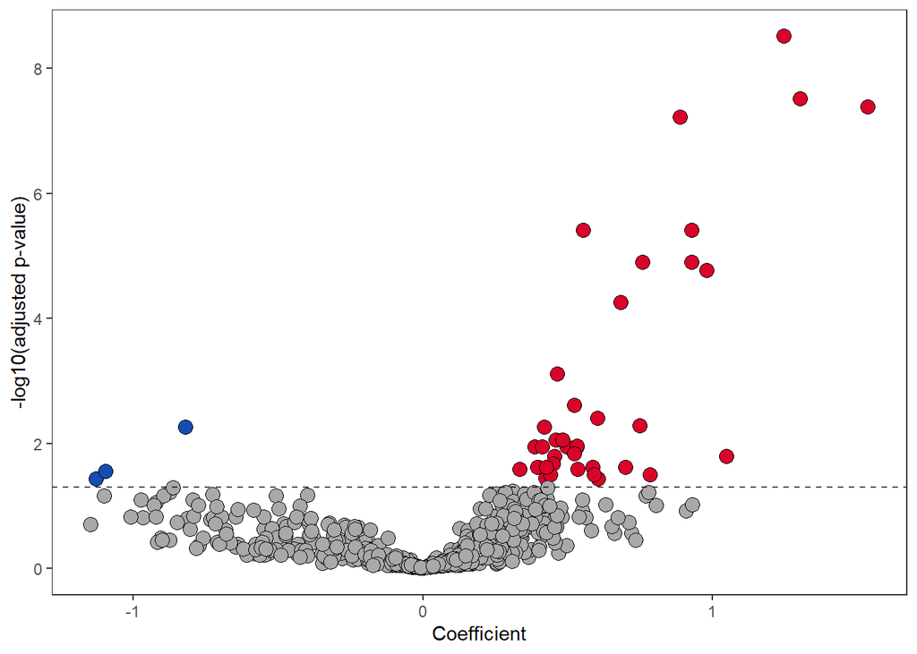

```r
ttest_results %>%
  ggplot(aes(x = estimate, y = log10adjustP, fill = Direction)) +
  geom_point(size = 3.5, shape = 21) +
  scale_fill_manual(values = c("#164db5", "darkgrey", "#d90429")) +
  theme_bw() +
  geom_hline(yintercept = 1.3, linetype = 2, alpha = 0.7) +
  xlab("Coefficient") +
  ylab("-log10(adjusted p-value)") +
  theme(legend.position= "none",
        panel.grid.major = element_blank(),
        panel.grid.minor = element_blank())
```

#### Visualization - Boxplot

Sometimes you want to plot one or a few specific proteins. If we look at the results dataframe we see that the proteins Q14767_LTBP2 and Q15113_PCOLCE are most significant. Lets plot these.

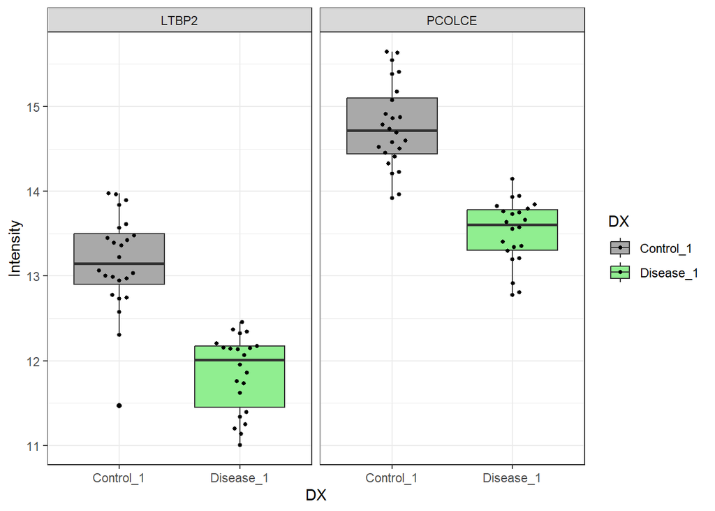

```r
clinical_and_protein_joined %>%

  #filter the original two groups, the two proteins and split the proteinnames again.
  filter(DX %in% c("Disease_1", "Control_1")) %>%
  filter(Protein %in% c("Q14767_LTBP2", "Q15113_PCOLCE")) %>%
  separate(Protein, c("UniprotID", "Gene")) %>%

  #Create the plot
  ggplot(aes(x = DX, y = Intensity, fill = DX)) +
  geom_boxplot() +
  geom_beeswarm(cex = 3, size = 1, color = "black") + #ADDS THE BLACK DOTS TO HELP INTERPRET THE DATA
  scale_fill_manual(values = c("Control_1" =  "darkgrey", "Disease_1" = "lightgreen")) +
  theme_bw() +

  #Split the plots by Gene. If we dont it will combine them which we do NOT want!!!!
  facet_wrap(~Gene)
```

### ANOVA

#### Running ANOVA

Similar to T-test we use Rstatix anova_test to do the actual testing.

If it prints these “Coefficient covariances computed by hccm()” things, update Rstatix to 0.7.1 or higher.

```r
anova_results <- clinical_and_protein_joined_atLeastTwo %>%
  drop_na(Intensity) %>%
  group_by(Protein) %>%
  anova_test(Intensity ~ DX, detailed = T) %>%
  adjust_pvalue(method = "BH") %>%
  separate(Protein, into = c("Uniprot", "Gene"), sep = "_", remove = F)
```

#### Visualization - Boxplot

Same thing as above, but now we do not filter for clinical groups.

We take the same proteins as above again.

Additionally, we can add post-hoc analysis. You might have to play a bit with the y-axis limits to make it fit!!

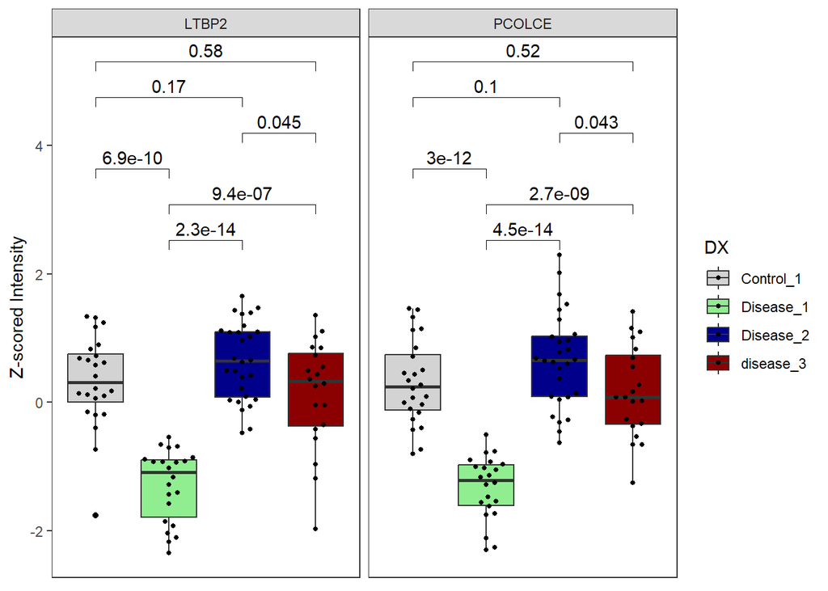

```r
#We need to specify which comparisons we want post-hoc to do.
my_comparisons <- list(
  c("Disease_1", "Disease_2"),
  c("Disease_1", "disease_3"),
  c("Disease_1", "Control_1"),
  c("Disease_2", "disease_3"),
  c("Disease_2", "Control_1"),
  c("disease_3", "Control_1")
  )


clinical_and_protein_joined_atLeastTwo %>%
  filter(Protein %in% c("Q14767_LTBP2", "Q15113_PCOLCE")) %>%

  #Z-score per protein. You can remove this if you want. Its can be nicer because you will have similar y-values
  group_by(Protein) %>%
  mutate(Zscore = scale(Intensity)) %>%

  #Clean so that you only Gene
  separate(Protein, c("Uniprot", "Gene")) %>%

  #plot
  ggplot(aes(x = DX, y = Zscore, fill = DX)) +
  geom_boxplot() +
  geom_beeswarm(cex = 3, size = 1, color = "black") +
  stat_compare_means(comparisons = my_comparisons) +
  scale_fill_manual(values = c("lightgrey", "lightgreen", "darkblue", "darkred")) +
  xlab("") +
  ylab("Z-scored Intensity") +
  facet_wrap(~Gene) +
  theme_bw() +
  theme(
    axis.title.x=element_blank(),
    axis.text.x=element_blank(),
    axis.ticks.x=element_blank(),
    panel.grid.major = element_blank(),
    panel.grid.minor = element_blank())
```

#### Visualization - Heatmap

Sometimes its nicer to plot ALL significant proteins in a heatmap. We can do that using the ComplexHeatmap Package.

For the heatmap we need a WIDE format dataframe, not a long(tidy) format. Its likely one of the few cases where wide is needed. Furthermore, we need a separate dataframe for the clinical values, and one for the protein info.

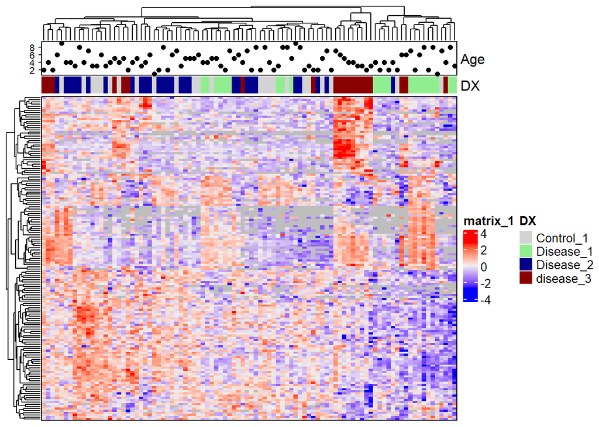

```r
#Filter for significant proteins, remove all clinical.
heatmap_wideDF_protein <- clinical_and_protein_joined_atLeastTwo %>%
  filter(Protein %in%
           filter(anova_results, p.adj < 0.05)$Protein) %>%
  group_by(Protein) %>%
  mutate(Intensity = scale(Intensity)) %>%
  ungroup() %>%
  spread(key = "Protein",
         value = "Intensity") %>%
  select(-SampleID, -DX, -Fake_Age)

#If you want the clinical variables on top (as we do here) you also need to put the sample names as columns. Thus we transpose.
heatmap_wideDF_protein <- data.frame(t(heatmap_wideDF_protein))

#filter for significant proteins, keep only clinical
heatmap_wideDF_clinical <- clinical_and_protein_joined_atLeastTwo %>%
  filter(Protein %in%
           filter(anova_results, p.adj < 0.05)$Protein) %>%
  spread(key = "Protein",
         value = "Intensity") %>%
  select(SampleID, DX, Fake_Age)

#Make the annotation (i.e. clinical variable info) for the Heatmap
heatmap_clinical_info <- HeatmapAnnotation(
  Age = anno_points(heatmap_wideDF_clinical$Fake_Age),
  DX = heatmap_wideDF_clinical$DX,
  col = list( #IN HERE WE SPECIFY COLOURS. THIS IS CURRENTLY ONLY RELEVANT FOR DISEASE!
    DX = c("Disease_1" = "lightgreen",
           "Disease_2" = "darkblue",
           "disease_3" = "darkred",
           "Control_1" = "lightgrey")
  )
)

#make the Heatmap
Heatmap(
  as.matrix(heatmap_wideDF_protein),

  #Specify some things. You can look up the package for whatever you want to change
  column_title_rot = 90,
  column_title_gp = gpar(fontsize=10),

  show_column_names = F,
  show_row_names = F,
  border_gp = gpar(col = "black", lwd = 1),
  top_annotation = heatmap_clinical_info
  )
```